# Introduction to $k$-NN: Classifying the Success of Terrorist Attacks

```python
# Import libraries
from sklearn.neighbors import KNeighborsClassifier
from sklearn.model_selection import train_test_split

import mglearn #library provided by amueller
import numpy as np

import matplotlib.pyplot as plt
import matplotlib.patches as patches
import pandas as pd
import plotly.express as px

from IPython.display import clear_output, HTML, display
import pprint
%matplotlib inline
```

```python
font = "Roboto-Regular.ttf"
pp = pprint.PrettyPrinter(indent=4, width=100)


HTML('''
<style>
.output_png {
    display: table-cell;
    text-align: center;
    vertical-align: middle;
}


</style>


<script>
code_show=true;
function code_toggle() {
 if (code_show){
 $('div.input').hide();
 } else {
 $('div.input').show();
 }
 code_show = !code_show
}
$( document ).ready(code_toggle);
</script>
<form action="javascript:code_toggle()"><input type="submit" value="Click here to toggle on/off the raw code."></form>
''')
```

```python
# Defining functions
def removecol(colname):
    """Function that will remove column name from the dataframe."""
    del df[colname]
    global numvars_dates
    global numvars_location
    global numvars_binary
    global numvars_category
    global numvars_freq
    global numvars_val
    global xvar
    xvar = [col for col in xvar if col != colname]
    numvars_dates = [col for col in numvars_dates if col != colname]
    numvars_location = [col for col in numvars_location if col != colname]
    numvars_binary = [col for col in numvars_binary if col != colname]
    numvars_category = [col for col in numvars_category if col != colname]
    numvars_freq = [col for col in numvars_freq if col != colname]
    numvars_val = [col for col in numvars_val if col != colname]


def success_by_pcc(df, y):
    """Returns acceptable PCC range"""
    pcc = 0
    N = df[y].size
    for state in df[y].unique():
        n = df[df[y] == state][y].size
        pcc += (n/N)**2
    return 1.25*pcc


def knn_plot(mean_train_accuracy, mean_test_accuracy,
             test_mean_plus_std, test_mean_minus_std,
             train_mean_plus_std, train_mean_minus_std,
             n_neighbors, title, caption, k, acc, w, h):
    """Plot the of model

    Parameters
    -------
    mean_train_accuracy: list
        Mean score of n `trials` from train data for each `k` neighbors
    mean_test_accuracy: list
        Mean score of n `trials` from test data for each `k` neighbors
    train_mean_plus_std: list
        Mean + StdDev score of n `trials` from train data for each `k`
    train_mean_minus_std: list
        Mean - StdDev score of n `trials` from train data for each `k`
    test_mean_plus_std: list
        Mean + StdDev score of n `trials` from test data for each `k`
    test_mean_minus_std: list
        Mean - StdDev score of n `trials` from train data for each `k`
    n_neighbors: range
        Range from 1 to `k` neighbors
    title: str

    caption: str

    k: float
        optimal k (minimum)
    acc: float
        occuracy
    w: float
        width of the rectangle (number of k's)
    h: float
        height of the rectangle
    """
    fig = plt.figure(figsize=(15, 8))
    ax = fig.add_subplot()
    plt.plot(n_neighbors, mean_train_accuracy,
             label="Training Accuracy", color='royalblue')
    plt.fill_between(n_neighbors, train_mean_plus_std, train_mean_minus_std,
                     color='lightsteelblue', alpha=0.8)

    plt.plot(n_neighbors, mean_test_accuracy,
             label="Test Accuracy", color='darkorange')
    plt.fill_between(n_neighbors, test_mean_plus_std, test_mean_minus_std,
                     color='peachpuff', alpha=0.8)

    fig.suptitle(title, fontsize=14, fontweight='bold')
    fig.subplots_adjust(top=0.93)
    ax.set_title(caption)
    ax.set_xlabel('$k$-Neighbors')
    ax.set_ylabel('Accuracy')
    rect = patches.Rectangle((k, acc), w, h,
                             linewidth=2.5,
                             edgecolor='r',
                             facecolor='none')
    ax.add_patch(rect)
    ax.legend()
```

# Problem

An act of terrorism is defined by the National Consortium for the Study of Terrorism and Responses to Terrorism (START) as the threatened or actual use of illegal force and violence by a non-state actor to attain a political, economic, religious, or social goal through fear, coercion, or intimidation. START maintains the Global Terrorism Database which has over 180,000 records of terrorist attacks since 1970.

Despite the comprehensive database, terrorist attacks are still largely unpredictable. Law enforcements heavily rely on intelligence or information from different reliable sources to prevent it. Yet, terrorist attacks can potentially be part of an international network or series of events resulting to patterns and similarities in their execution.

Given data from previous terrorist attacks, our model aims to predict whether or not a terrorist attack will be successful. Knowing which terrorist attacks will likely be successful can allow law enforcers to focus their resources into preventing it and thus save more lives.

# Highlights

# Data Discussion

The Global Terrorism Database was downloaded from [Kaggle](https://www.kaggle.com/START-UMD/gtd). This was released last July 2018 and the full data covers years from 1970 to 2017. The dataset contains 181,691 rows and 135 columns. For more information, you may view the documentation [here](https://www.start.umd.edu/gtd/downloads/Codebook.pdf).

### Data Processing

Data processing was implemented on the raw data. The scope of the data processing are as follows:

- Filtering the data to only consider the year 2017
- Selecting features as described in Table 1. These features can be measured or estimated using intelligence reports prior to an attack.
- Removing NAN rows

**Table 1. Features**

| Data | Data Type | Description |
| --- | --- | --- |
| `latitude` | Float | Latitude (based on WGS1984 standards) of the city where the event occurred |
| `longitude` | Float | Longitude (based on WGS1984 standards) of the city where the event occurred |
| `suicide` | Integer | Occurrence of a suicide attack |
| `individual` | Integer | Tag whether the attackers is an individual or a group |
| `property` | Integer | Tag whether the incident resulted in property damage or not |
| `extended` | Integer | Duration of the incident |
| `specificity` | Integer | Location of the city, village, or town where the event occurred |
| `attacktype1` | Integer | General method of attack and often reflects the broad class of tactics used |
| `targtype1` | Integer | The type of target/victim, person, entity, organization, facility or infrastructure |
| `weaptype1` | Integer | The type of weapon used |
| `nperps` | Integer | Total number of terrorists participating in the incident |
| `nkill` | Integer | Total confirmed fatalities for the incident |
| `nwound` | Integer | Total number of confirmed non-fatal injuries for both perpetrators and victims |

**Table 2. Target Variable**

| Data | Data Type | Description |
| --- | --- | --- |
| `success` | Integer | Outcome of terrorist attack |

#### The final data set consists of 13 features and a target variable `success`. The data set contains 5,958 rows and 14 columns. The rate of `success` in the dataset is $76.44\%$.

```python
# Columns Chosen (will include descriptions)
numvars_dates = ['iyear', 'imonth', 'iday']

numvars_location = ['longitude', 'latitude']

numvars_binary = ['multiple', 'suicide', 'individual', 'property',
                  'extended']
numvars_category = ['specificity',
                    'attacktype1', 'attacktype2', 'attacktype3',
                    'targtype1', 'targtype2', 'targtype3',
                    'weaptype1', 'weaptype2', 'weaptype3',
                    'propextent']
numvars_freq = ['nperps', 'nkill', 'nwound']
numvars_val = ['propvalue']

xvar = numvars_dates + numvars_location + numvars_binary + \
    numvars_category + numvars_freq + numvars_val
y = 'success'

# Import data
df = pd.read_csv('globalterrorismdb_0718dist.csv', encoding='iso-8859-1',
                 nrows=181692, header=0, index_col='eventid',
                 usecols=['eventid'] + xvar + [y], low_memory=False)

# Filter data
df = (df[
    (df['iyear'] >= 2017) &  # ISIS started beheadings AND
    ((~df['attacktype1'].isin([5, 6, 9])) &  # Incidents need to have NO
     (~df['attacktype2'].isin([5, 6, 9])) &  # hostage-taking related type
     (~df['attacktype3'].isin([5, 6, 9]))) &  # of attack.
    (df['multiple'] == 0)  # singular incidents
].copy())

# Drop columns
removecol('iyear')
removecol('imonth')
removecol('iday')
removecol('multiple')

# Nullify binary variables to only include 1,0 or np.nan
df[numvars_binary] = df[numvars_binary].applymap(
    lambda x: x if x in [0,1] else np.nan)

#check nan treshhold percentage by basing on mean
des = df[xvar].describe(include = 'all')

des.loc['dtype'] = df.dtypes
des.loc['size'] = len(df)
des.loc['% count'] = df.isnull().mean()

nan_threshold = des.loc['% count',:].mean()


# Get list of acceptable nan columns
des_series = des.loc['% count',:]
xvar_final = list(des_series[des.loc['% count',:]<nan_threshold].index)

# Create dfterr main data
dfterr = df[xvar_final+[y]].dropna(how='any').copy()
x = list(dfterr.columns)
x.remove(y)

dfterr.head(5)
```

| eventid | longitude | latitude | suicide | individual | property | extended | specificity | attacktype1 | targtype1 | weaptype1 | nperps | nkill | nwound | success |
| --- | --- | --- | --- | --- | --- | --- | --- | --- | --- | --- | --- | --- | --- | --- |
| 201612270022 | 24.318324 | 12.921007 | 0 | 0 | 1.0 | 0 | 1.0 | 2 | 14 | 5 | -99.0 | 2.0 | 0.0 | 1 |
| 201701010001 | 28.689863 | 41.106178 | 0 | 0 | 1.0 | 0 | 1.0 | 2 | 1 | 5 | 1.0 | 39.0 | 69.0 | 1 |
| 201701010005 | 71.382386 | 34.824085 | 0 | 0 | 0.0 | 0 | 2.0 | 3 | 3 | 6 | -99.0 | 1.0 | 0.0 | 1 |
| 201701010006 | 11.255814 | 43.769560 | 0 | 0 | 1.0 | 0 | 1.0 | 3 | 1 | 6 | 5.0 | 0.0 | 1.0 | 1 |
| 201701010008 | 28.689863 | 41.106178 | 0 | 0 | 0.0 | 0 | 1.0 | 2 | 15 | 5 | 1.0 | 0.0 | 2.0 | 1 |

Terrorism is a global problem but this is often concentrated in certain areas. In 2017, it can be observed that the attacks were prevalent in the Middle East and even in the Philippines.

```python
df_longxlat = dfterr[['latitude', 'longitude', 'success']].reset_index()
df_longxlat['success'] = df_longxlat['success'].apply(lambda x: 'Yes' if x == 1 else 'No')
# Set mapbox access token

with open('mapbox_key.txt') as f:
    mapbox = f.read().strip()
px.set_mapbox_access_token(mapbox)
# Plot merge_df
fig = px.scatter_mapbox(df_longxlat,
                        lon='longitude',
                        lat='latitude',
                        mapbox_style='dark',
                        color = 'success',
                        color_discrete_map = {'Yes': 'red', 'No': 'blue'},
                        opacity=0.5,
                        zoom=1,
                        width=900,
                        height=500)

fig.show(renderer='notebook')
```

[interactive chart not shown]

#### Figure 1. Global Terrorist Attacks in 2017

# Implementation

### $k$-NN Implementation

```
Progress:...Completed
```

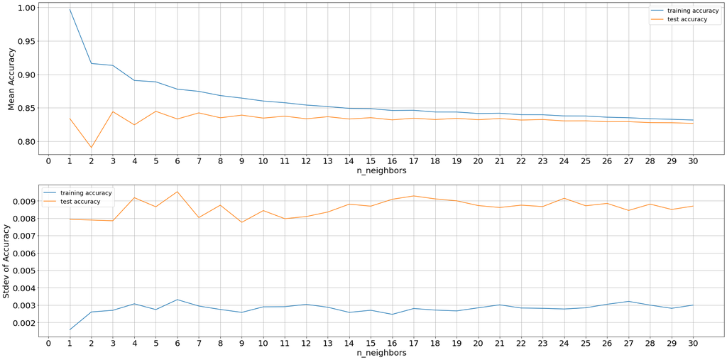

```python
# Generate random numbers as random state values for the 100 trials
# (for randomness and repeatability)
np.random.seed(2222)
rng = np.random.randint(0, 1_000_000, 50)


# Initialize 100 iterations level mean and std lists
training_accuracy_mean = []
training_accuracy_std  = []
test_accuracy_mean = []
test_accuracy_std  = []

# Loop through neighbor values
neighbors_settings = range(1, 31)

for k in neighbors_settings:

    # Initializie list for current neighbor k
    training_accuracy = []
    test_accuracy = []

    # Commence 100 iterations
    for c,i in enumerate(rng):

        # Create training-test data with random state based on i
        X_train, X_test, y_train, y_test = (train_test_split(
            dfterr[x], dfterr[y], stratify = dfterr[y],
            test_size=0.25, random_state=i))

        # Build Model
        clf = KNeighborsClassifier(n_neighbors=k)
        clf.fit(X_train, y_train)

        # Record current training set accuracy iteration
        training_accuracy.append(clf.score(X_train, y_train))

        # Record current test set accuracy iteration
        test_accuracy.append(clf.score(X_test, y_test))

        # Update User - for sense of peace that it works (less paranoia)
        print('Progress:...k={}...trial={}'.format(str(k).zfill(2),c))
        clear_output(wait=True)

    # Record mean and std of the 100 iteration accuracies for current k
    training_accuracy_mean.append(np.mean(training_accuracy))
    training_accuracy_std.append(np.std(training_accuracy))
    test_accuracy_mean.append(np.mean(test_accuracy))
    test_accuracy_std.append(np.std(test_accuracy))

print( "Progress:...Completed")

# Plotting
fig,ax = plt.subplots(2,1,figsize = (30,15))

ax[0].set_xticks(np.arange(min(neighbors_settings)-1, max(neighbors_settings)+1, 1.0))
ax[0].plot(neighbors_settings, training_accuracy_mean, label="training accuracy")
ax[0].plot(neighbors_settings, test_accuracy_mean, label="test accuracy")
ax[0].set_ylabel("Mean Accuracy", fontsize=20)
ax[0].set_xlabel("n_neighbors", fontsize=20)
ax[0].tick_params(axis='both', which='major', labelsize=20)
ax[0].tick_params(axis='both', which='minor', labelsize=18)
ax[0].legend(fontsize="x-large")
ax[0].grid()

ax[1].set_xticks(np.arange(min(neighbors_settings)-1, max(neighbors_settings)+1, 1.0))
ax[1].plot(neighbors_settings, training_accuracy_std, label="training accuracy")
ax[1].plot(neighbors_settings, test_accuracy_std, label="test accuracy")
ax[1].set_ylabel("Stdev of Accuracy", fontsize=20)
ax[1].set_xlabel("n_neighbors", fontsize=20)
ax[1].tick_params(axis='both', which='major', labelsize=20)
ax[1].tick_params(axis='both', which='minor', labelsize=18)
ax[1].legend(fontsize="x-large")
ax[1].grid()

plt.show();
pass
```

```python
performance = pd.DataFrame(
    {'training_accuracy_mean': training_accuracy_mean,
     'training_accuracy_std': training_accuracy_std,
     'test_accuracy_mean': test_accuracy_mean,
     'test_accuracy_std': test_accuracy_std
    }).to_csv('performance_k30t50.csv',index=False)
```

# Discussion of Results

Our model uses $k$-NN classification. $k$-NN categorizes training data into groups according to our assigned predictors. When it is given new data, it will be predicting the target result based on which ‘group’ it is closest to. This logic is like the saying, ‘birds of a feather, flock together’. For more information you can refer to [this](https://en.wikipedia.org/wiki/K-nearest_neighbors_algorithm).

For our model, we wanted to predict the outcome of terrorist attacks. By using $k$-NN on terror attacks data from our ‘Global Terrorism Database Dataset’, we would try to predict whether an attack would likely end in a success or failure. Using our basic understanding of terrorism, we arbitrarily selected a few predictors available in the dataset we think would be most helpful in predicting the success of a terror attack considering the measurability and natural implications. We chose features that are can be obtained through counter-terrorist intelligence sources like surveillance, anonymous tips, and other sources.

The model obtained a training accuracy of $88.88\%$ and test accuracy of $84.47\%$ at $k=5$. Note, however, that the data is imbalanced with $76.44\%$ success which could have possible contributed to the accuracy. Nonetheless, a classifier machine learning model is considered highly succcesful when the test accuracy exceeds $1.25\mathbf{P}_{CC}$ which in our case is $79.97\%$. Our model was able to meet this criteria.

In order to defeat your enemy, one strategy is to think like your enemy.

[figure not shown]

```python
df_results = pd.read_csv('performance_k30t50.csv')
mean_train_accuracy = df_results['training_accuracy_mean'].to_list()
mean_test_accuracy =  df_results['test_accuracy_mean'].to_list()
test_mean_plus_std =  (df_results['test_accuracy_mean'] + df_results['test_accuracy_std']).to_list()
test_mean_minus_std = (df_results['test_accuracy_mean'] - df_results['test_accuracy_std']).to_list()
train_mean_plus_std = (df_results['training_accuracy_mean'] + df_results['training_accuracy_std']).to_list()
train_mean_minus_std = (df_results['training_accuracy_mean'] - df_results['training_accuracy_std']).to_list()

n_neighbors = range(1,31)
title = 'Global Terrorism Data - KNN Classification'
caption = 'Accuracy vs Number of Neighbors; $k = 30$, $trials = 100$'

knn_plot(mean_train_accuracy, mean_test_accuracy,
         test_mean_plus_std, test_mean_minus_std,
         train_mean_plus_std, train_mean_minus_std,
         n_neighbors, title, caption, 4.5, 0.82, 1.5, 0.075)
```